# Chap 9.Visualizing data distribution

# **9.0 Intro**

Numerical data **–summarize–>** *average value*, *standard deviation*

Is this appropriate? Is there any important piece of information that we are *missing* by only looking at this summary rather than the entire list?

> It is better method to show entire distribution There’s a posibility of missing, but informative data.

```
You may have noticed that numerical data is often summarized with the average value. For example, the quality of a high school is sometimes summarized with one number: the average score on a standardized test. Occasionally, a second number is reported: the standard deviation. For example, you might …

Our first data visualization building block is learning to summarize lists of factors or numeric vectors. More often than not, the best way to share or explore this summary is through data visualization. The most basic statistical summary of a list of objects or numbers is its distribution. Once a v…

In this Chapter, we first discuss properties of a variety of distributions and how to visualize distributions using a motivating example of student heights. We then discuss the ggplot2 geometries for these visualizations in Section 9.16.
```

# **9.1 Variable types**

Two types of variables

1. categorical : each entry in a vector comes from one of a small number of groups
   - ordinal : ordered categorical data
   - non-ordinal
2. numeric
   - discete : can be considered ordinal
   - continuous

```
We will be working with two types of variables: categorical and numeric. Each can be divided into two other groups: categorical can be ordinal or not, whereas numerical variables can be discrete or continuous.

When each entry in a vector comes from one of a small number of groups, we refer to the data as categorical data. Two simple examples are sex (male or female) and regions (Northeast, South, North Central, West). Some categorical data can be ordered even if they are not numbers per se, such as spicin…

Example of numerical data are population sizes, murder rates, and heights. Some numerical data can be treated as ordered categorical. We can further divide numerical data into continuous and discrete. Continuous variables are those that can take any value, such as heights, if measured with enough pr…

Keep in mind that discrete numeric data can be considered ordinal. Although this is technically true, we usually reserve the term ordinal data for variables belonging to a small number of different groups, with each group having many members. In contrast, when we have many groups with few cases in e…
```

# **9.2 Case study : describing student heights**

|  | sex | height |
| --- | --- | --- |
| 1 | Male | 75 |
| 2 | Male | 70 |
| 3 | Male | 68 |
| 4 | Male | 74 |
| 5 | Male | 61 |
| 6 | Female | 65 |

```
Here we introduce a new motivating problem. It is an artificial one, but it will help us illustrate the concepts needed to understand distributions.

Pretend that we have to describe the heights of our classmates to ET, an extraterrestrial that has never seen humans. As a first step, we need to collect data. To do this, we ask students to report their heights in inches. We ask them to provide sex information because we know there are two differen…

One way to convey the heights to ET is to simply send him this list of 1050 heights. But there are much more effective ways to convey this information, and understanding the concept of a distribution will help. To simplify the explanation, we first focus on male heights. We examine the female height…
```

# **9.3 Distribution function ; for categorical variables**

> In some cases, the **average** and the **standard deviation** are pretty much all we need to understand the data.

> basic statistical summary of a list of object
- frequency table

| sex | frequency |
| --- | --- |
| Female | 0.2266667 |
| Male | 0.7733333 |

- simple barplot : if there are more categories, then a simple barplot describes the distribution. (for a few numbers of categories )

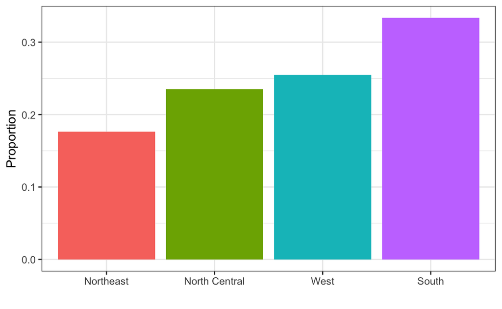

simple barplot

```
It turns out that, in some cases, the average and the standard deviation are pretty much all we need to understand the data. We will learn data visualization techniques that will help us determine when this two number summary is appropriate. These same techniques will serve as an alternative for whe…

The most basic statistical summary of a list of objects or numbers is its distribution. The simplest way to think of a distribution is as a compact description of a list with many entries. This concept should not be new for readers of this book. For example, with categorical data, the distribution s…

This two-category frequency table is the simplest form of a distribution. We don’t really need to visualize it since one number describes everything we need to know: 23% are females and the rest are males. When there are more categories, then a simple barplot describes the distribution. Here is an e…

This particular plot simply shows us four numbers, one for each category. We usually use barplots to display a few numbers. Although this particular plot does not provide much more insight than a frequency table itself, it is a first example of how we convert a vector into a plot that succinctly sum…
```

# **9.4 Cumilative distribution functions ; for numerical variables**

> Cumulative distribution function(CDF) : reports the proportion of the data below $a$ for all possible values of $a$.

> $F(a) = Pr(x<=a)$
- a plot of $F$ for the male height data:

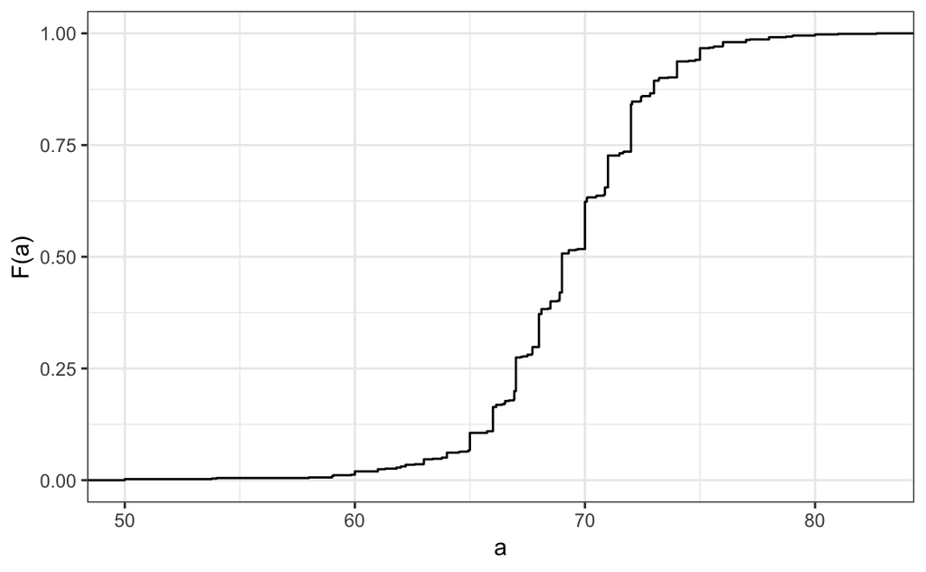

cumulative function

- $F(b)-F(a)$ : the proportion of values between any two heights, say a and b

> A final note: because CDFs can be defined mathematically the word empirical is added to make the distinction when data is used. We therefore use the term **empirical CDF (eCDF)**.

```
Numerical data that are not categorical also have distributions. In general, when data is not categorical, reporting the frequency of each entry is not an effective summary since most entries are unique. In our case study, while several students reported a height of 68 inches, only one student repor…

Statistics textbooks teach us that a more useful way to define a distribution for numeric data is to define a function that reports the proportion of the data below a for all possible values of a. This function is called the cumulative distribution function (CDF). In statistics, the following notati…

F(a) = Pr(x<=a)

Here is a plot of  F  for the male height data:

Similar to what the frequency table does for categorical data, the CDF defines the distribution for numerical data. From the plot, we can see that 16% of the values are below 65, since F ( 66 ) = 0.164, or that 84% of the values are below 72, since F ( 72 ) = 0.841, etc.. In fact, we can report the …
```

# **9.5 Histograms**

> Histograms are much easier to interpret than CDF.
- Histograms of non-overlappping bins
  - x axis : numerical (not categorical)
  - y axis : count as frequency

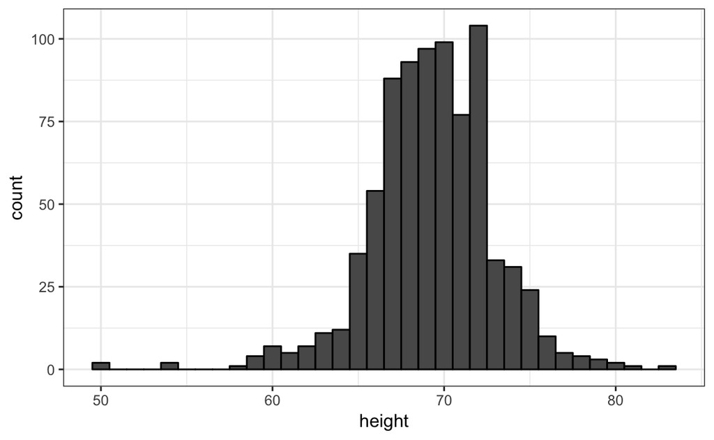

histograms

> But it is less informative than CDF.
- all values in each interval are treated the same when computing bin heights.

```
Although the CDF concept is widely discussed in statistics textbooks, the plot is actually not very popular in practice. The main reason is that it does not easily convey characteristics of interest such as: at what value is the distribution centered? Is the distribution symmetric? What ranges conta…

As you can see in the figure above, a histogram is similar to a barplot, but it differs in that the x-axis is numerical, not categorical.

If we send this plot to ET, he will immediately learn some important properties about our data. First, the range of the data is from 50 to 84 with the majority (more than 95%) between 63 and 75 inches. Second, the heights are close to symmetric around 69 inches. Also, by adding up counts, ET could o…

What information do we lose? Note that all values in each interval are treated the same when computing bin heights. So, for example, the histogram does not distinguish between 64, 64.1, and 64.2 inches. Given that these differences are almost unnoticeable to the eye, the practical implications are n…

We discuss how to code histograms in Section 9.16.
```

# **9.6 Smoothed density**

- Smoothed density
  - x axis : numerical (not categorical)
  - y axis : density as frequency (not count)

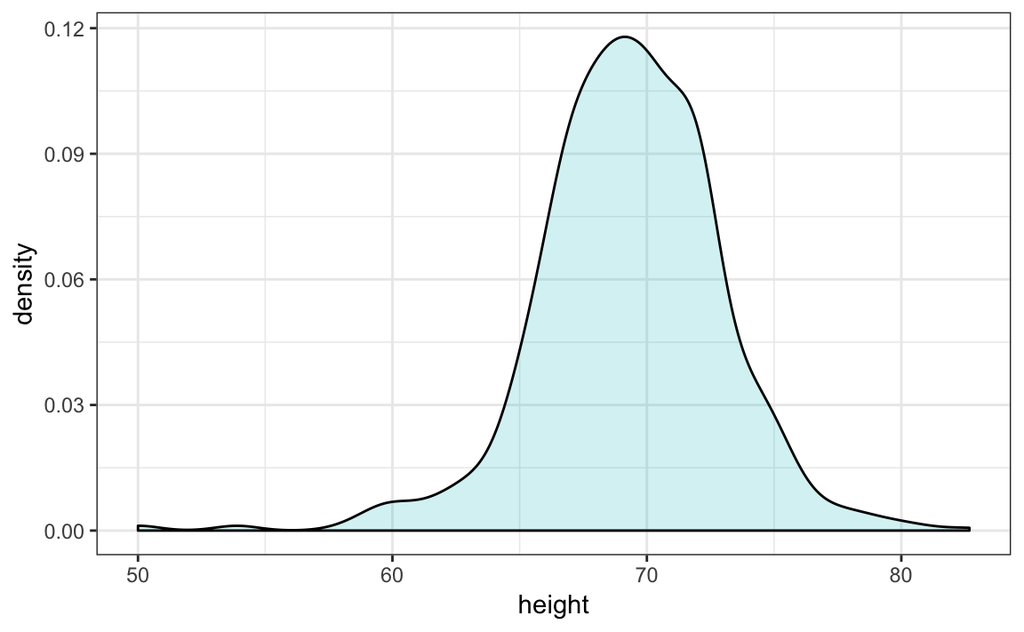

Smoothed density

> CDFs are empirical visualization, wherase Smooth density plots are estimated visualization.
- *estimates*
  - assume that our list of observed values is a subset of a much larger list of unobserved values.
  - bins of size 1 :

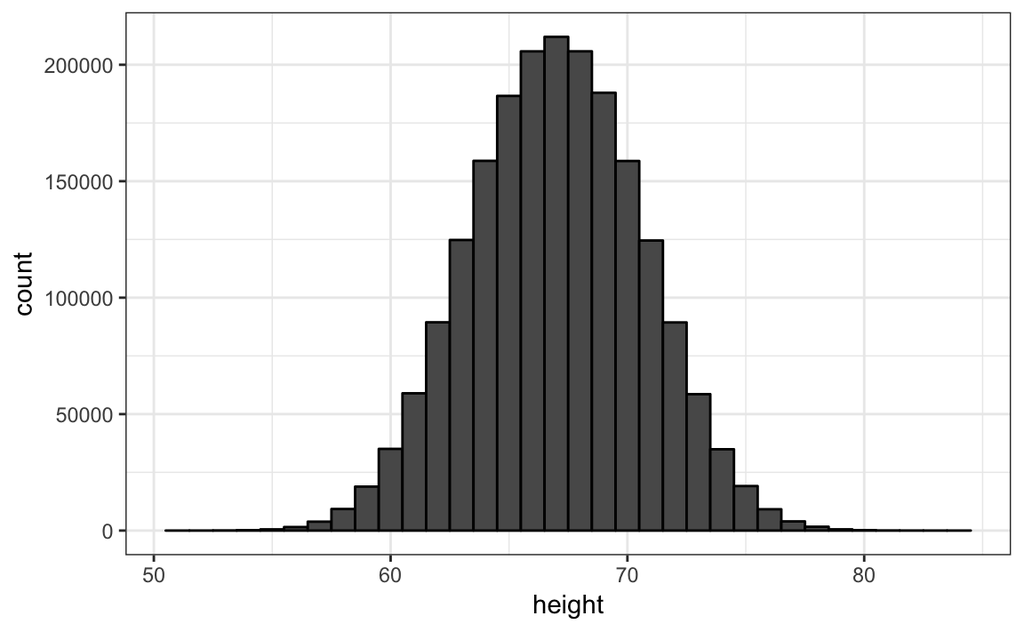

  size 1

  - adjusted binwidth

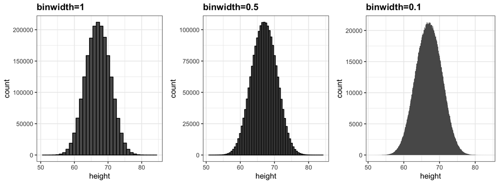

  adjusted

  - very, very small bins

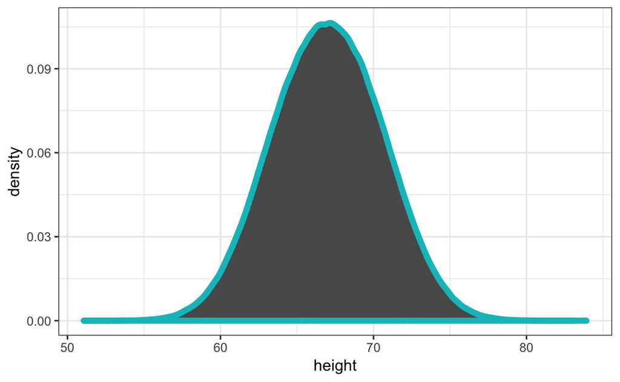

  smooth

- *smoothness* of the curve can be controlled.

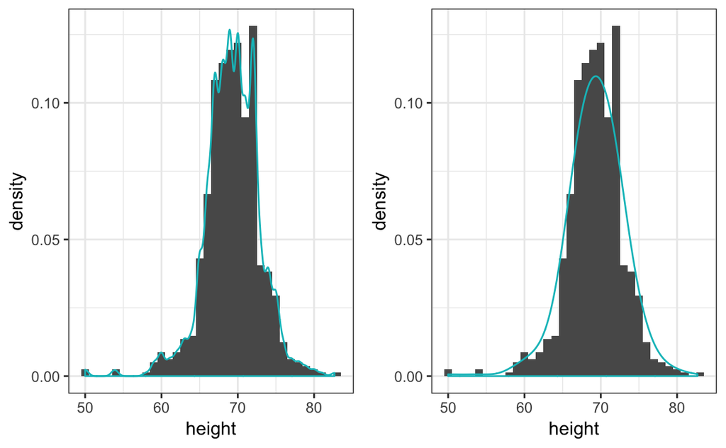

  smoothness

  - We should select a degree of smoothness that we can defend as being representative of the underlying data.

[output not shown]

## 9.6.1 interpreting the y-axis

- Area : the proportion of data in the interval
- the area under the density curve adds up to 1

[output not shown]

## 9.6.2 Densities permit stratification

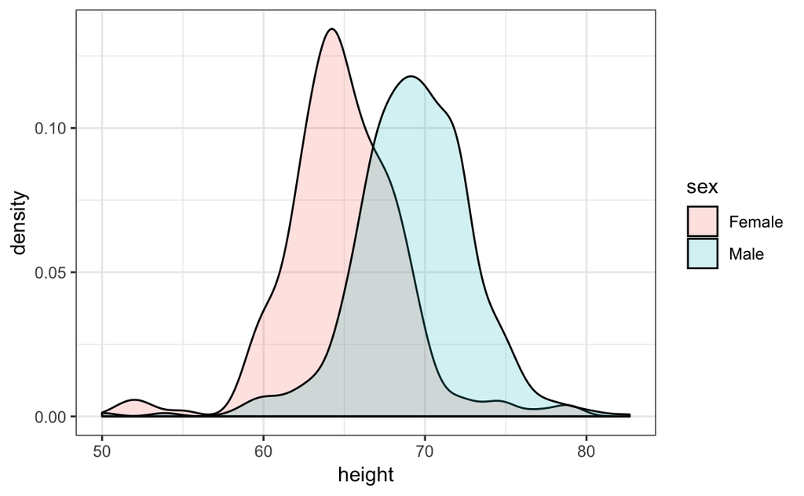

stratification

```
As a final note, we point out that an advantage of smooth densities over histograms for visualization purposes is that densities makes it easier to compare two distributions. This is in large part because the jagged edges of the histogram add clutter. Here is an example comparing male and female hei…

With the right argument, ggplot automatically shades the intersecting region with a different color. We will show examples of ggplot2 code for densities in Section 10 as well as Section 9.16.
```

# **9.7 Exercises**

1. In the `murders` dataset, the region is a categorical variable and the following is its distribution:

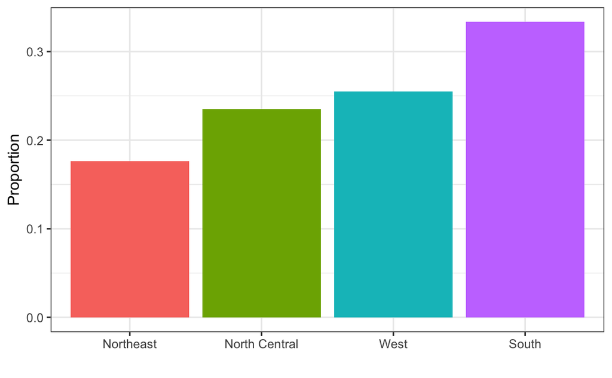

distribution

To the closet 5%, what proportion of the states are in the North Central region?

2. Which of the following is true:

A. The graph above is a histogram.

**B. The graph above shows only four numbers with a bar plot.**

C. Categories are not numbers, so it does not make sense to graph the distribution.

D. The colors, not the height of the bars, describe the distribution.

3. The plot below shows the eCDF for male heights:

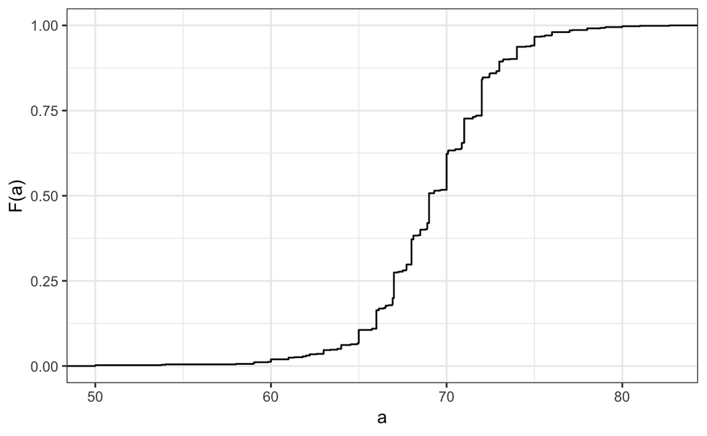

eCDF

Based on the plot, what percentage of males are shorter than 75 inches?

A. 100%

**B. 95%**

C. 80%

D. 72 inches

4. To the closest inch, what height m has the property that 1/2 of the male students are taller than m and 1/2 are shorter?

A. 61 inches

B. 64 inches

**C. 69 inches**

D. 74 inches

5. Here is an eCDF of the murder rates across states:

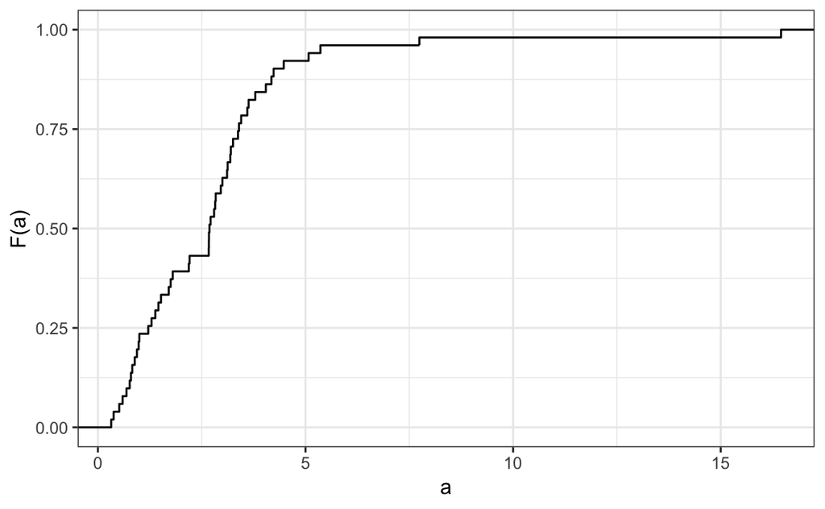

eCDF

Knowing that there are 51 states (counting DC) and based on this plot, how many states have murder rates larger than 10 per 100,000 people?

**A. 1**

B. 5

C. 10

D. 50

6. Based on the eCDF above, which of the following statements are true:

A. About half the states have murder rates above 7 per 100,000 and the other half below.

B. Most states have murder rates below 2 per 100,000.

C. All the states have murder rates above 2 per 100,000.

**D. With the exception of 4 states, the murder rates are below 5 per 100,000.**

7. Below is a histogram of male heights in our heights dataset:

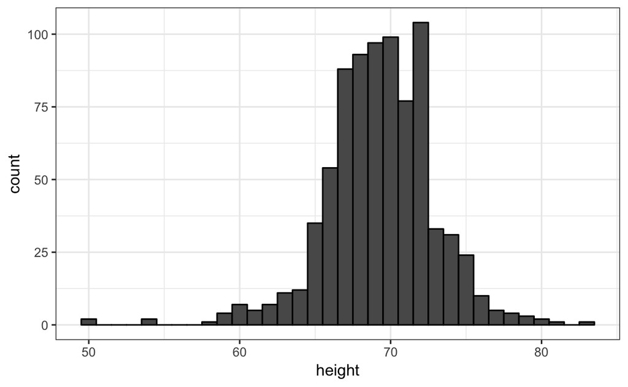

histogram

Based on this plot, how many males are between 63.5 and 65.5?

A. 10

B. 24

**C. 34**

D. 100

8. About what percentage are shorter than 60 inches?

**A. 1%**

B. 10%

C. 25%

D. 50%

9. Based on the density plot below, about what proportion of US states have populations larger than 10 million?

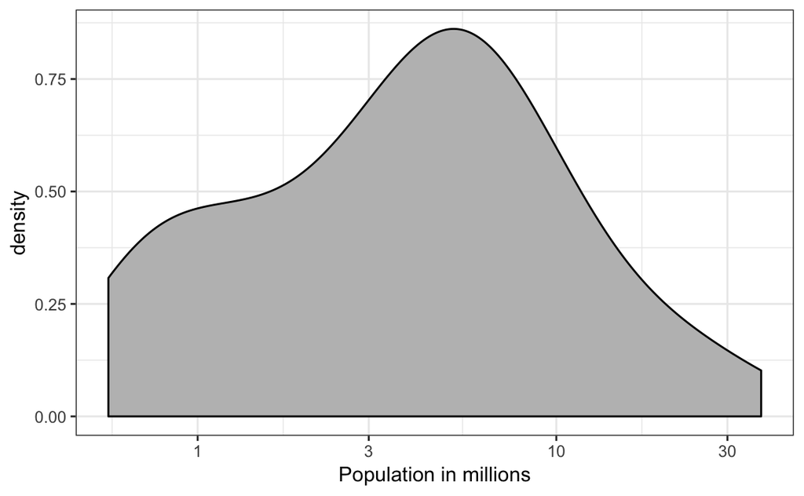

density

A. 0.02

**B. 0.15**

C. 0.50

D. 0.55

- y-axis scale 오류 아닌가?
10. Below are three density plots. Is it possible that they are from the same dataset?

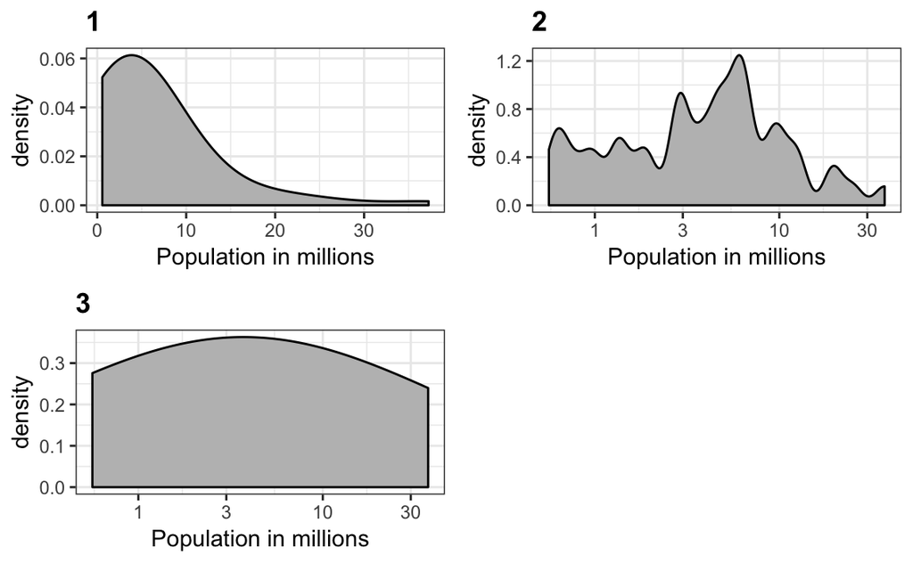

plots

Which of the following statements is true:

B. They are from the same dataset, but the plots are different due to code errors.

C. They are the same dataset, but the first and second plot undersmooth and the third oversmooths.

D. They are the same dataset, but the first is not in the log scale, the second undersmooths and the third oversmooths.

# **9.8 The normal distribution**

> Normal distribution(Gaussian distribution) : two value summary_the average and standard deviation used as summary statistics

```
* average(mean, $m$)
```

```
#definition of average
m <- sum(x) / length(x)
```

```
* standard deviation(DS ,$s$)
```

```
#definition of standard deviation
s <- sqrt(sum((x-mu)^2) / length(x))
```

> Standard normal distribution : $m=0$, $s=1$

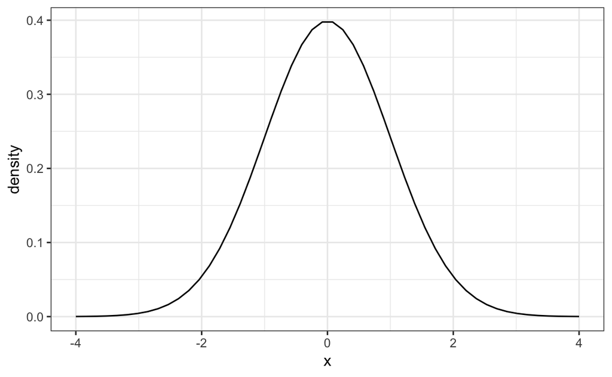

> Compare the normal distribution and empirical density plot

```r
c(average = m, sd = s)
```

```
  average        sd
69.314755  3.611024
```

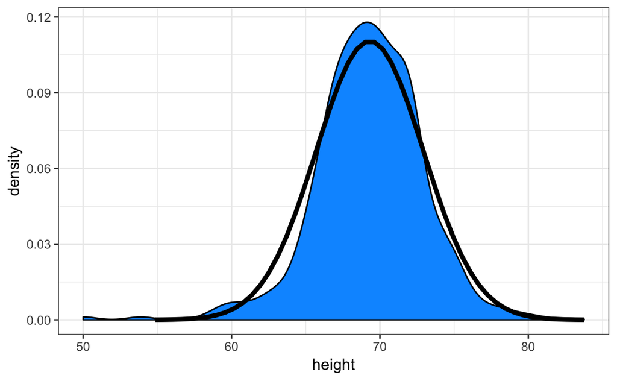

comparison

```
Histograms and density plots provide excellent summaries of a distribution. But can we summarize even further? We often see the average and standard deviation used as summary statistics: a two-number summary! To understand what these summaries are and why they are so widely used, we need to understa…

You don’t need to memorize or understand the details of the formula. But note that it is completely defined by just two parameters: m and s . The rest of the symbols in the formula represent the interval ends that we determine, a and b , and known mathematical constants π and e . These two parameter…

The fact that the distribution is defined by just two parameters implies that if a dataset is approximated by a normal distribution, all the information needed to describe the distribution can be encoded in just two numbers: the average and the standard deviation. We now define these values for an a…

For a list of numbers contained in a vector x, the average is defined as:

and the SD is defined as:

which can be interpreted as the average distance between values and their average. Let’s compute the values for the height for males which we will store in the object x :

Here is a plot of the smooth density and the normal distribution with mean = 69.3 and SD = 3.6 plotted as a black line with our student height smooth density in blue:

The normal distribution does appear to be quite a good approximation here. We now will see how well this approximation works at predicting the proportion of values within intervals.
```

# **9.9 Standard units**

> standard unit : `z = (x - m)/s`

```
* value `x` from a vector `x`
```

```r
class(z)
```

```
[1] "matrix"
```

```r
#calculate the proportion by standard deviation
mean(abs(z) < 2)
```

```
[1] 0.9495074
```

```
* the proportion is predicted by the normal distribution

* To further confirm that we can use quantile-quantile plots for approximation
```

```
For data that is approximately normally distributed, it is convenient to think in terms of standard units. The standard unit of a value tells us how many standard deviations away from the average it is. Specifically, for a value x from a vector X, we define the value of x in standard units as z = (x…

First look back at the formula for the normal distribution and note that what is being exponentiated is − z 2 / 2 with z equivalent to x in standard units. Because the maximum of e − z 2 / 2 is when z = 0 , this explains why the maximum of the distribution occurs at the average. It also explains the…

In R, we can obtain standard units using the function scale:

Now to see how many men are within 2 SDs from the average, we simply type:

The proportion is about 95%, which is what the normal distribution predicts! To further confirm that, in fact, the approximation is a good one, we can use quantile-quantile plots.
```

# **9.10 Quantile-quantile plots(QQ plots)**

> QQ plots : A systematic way to assess how well the normal distribution fits the data is to check if the **observed** and **predicted** proportions match.
- $\Phi(x)$ : the probability of a standard normal distribution being smaller than `x`
  - e.g. $\Phi(-1.96)=0.025$, $\Phi(1.96)=0.975$
  - In R, we can evaluate $\Phi$ using the `pnorm` function

```r
pnorm(-1.96)
```

```
[1] 0.0249979
```

- Theoretical quantile for the normal distribution : $\Phi^{-1}(x)$, calculation related to quantiles done without data
  - e.g. $\Phi^{-1}(0.975)=1.96$
  - In R, we can evaluate the inverse of $\Phi$ using the `qnorm` function

```r
qnorm(0.975)
```

```
[1] 1.959964
```

- for any normal distribution : using the `mean` and `sd` arguments in the `pnorm` and `qnorm`

```r
qnorm(0.975, mean = 5, sd = 2)
```

```
[1] 8.919928
```

- Theoretical quantile for any data in a vector $x$ : any proportion $p$ as the $q$ for which the proportion of values below $q$
  - In R, `q` can be defined as `mean(x <= q) = p`
  - It’s also evalusted by `quantile` function

```r
# it's proportion below the variables
mean(x <= 69.5)
```

```
[1] 0.5147783
```

- **QQ-plot** : comparing the observed quantile and expected quantile(by normal distribution)

```r
p
```

```
 [1] 0.05 0.10 0.15 0.20 0.25 0.30 0.35 0.40 0.45 0.50 0.55 0.60 0.65
[14] 0.70 0.75 0.80 0.85 0.90 0.95
```

```r
sample_quantiles
```

```
      5%      10%      15%      20%      25%      30%      35%      40%
63.90079 65.00000 66.00000 67.00000 67.00000 68.00000 68.00000 68.62236
     45%      50%      55%      60%      65%      70%      75%      80%
69.00000 69.00000 70.00000 70.00000 70.86614 71.00000 72.00000 72.00000
     85%      90%      95%
72.44000 73.22751 75.00000
```

```r
theoretical_quantiles
```

```
 [1] 63.37515 64.68704 65.57217 66.27564 66.87916 67.42113 67.92335
 [8] 68.39991 68.86099 69.31475 69.76852 70.22960 70.70616 71.20838
[15] 71.75035 72.35387 73.05734 73.94247 75.25436
```

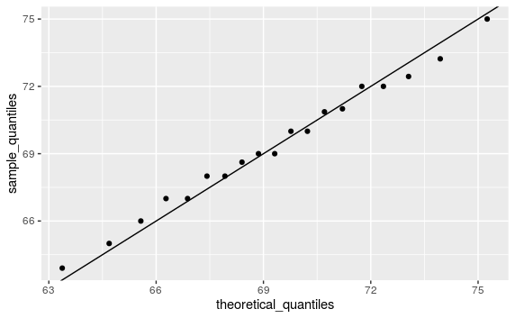

```
+ using **ggplot2**
```

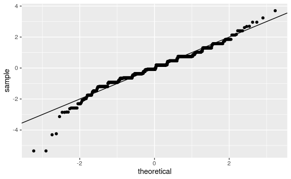

# **9.11 Percentiles**

- percentiles : special cases of quantiles. $q$(statistical variables) from any $p$
  - quantiles are obtained when setting $p = 0.25, 0.50, 0.75$

```
Before we move on, let’s define some terms that are commonly used in exploratory data analysis.
Percentiles are special cases of quantiles that are commonly used. The percentiles are the quantiles you obtain when setting the p at 0.01 , 0.02 , . . . , 0.99 . We call, for example, the case of p = 0.25 the 25th percentile, which gives us a number for which 25% of the data is below. The most famo…
For the normal distribution the median and average are the same, but this is generally not the case.
Another special case that receives a name are the quartiles, which are obtained when setting p = 0.25 , 0.50 , and 0.75 .
```

# **9.12 Boxplots**

> Boxplots : 5 number summary of dataset with the quantiles and the outliers(out of interquantile range)

# **9.13 Stratification**

- Stratification : divide observations into groups based on the values of one or more variables associated with those observations(clustering)
  - strata : the resulting group

```
In data analysis we often divide observations into groups based on the values of one or more variables associated with those observations. For example in the next section we divide the height values into groups based on a sex variable: females and males. We call this procedure stratification and ref…

Stratification is common in data visualization because we are often interested in how the distribution of variables differ across different subgroups. We will see several examples throughout this part of the book. We will revisit the concept of stratification when we learn regression in Chapter 18 a…
```

# **9.14 Case study : describing student heights (continued)**

```r
heights %>% filter(sex=="Female") %>%
    top_n(5, desc(height)) %>%
    pull(height)
```

```
[1] 51 53 55 52 52
```

# **9.15 Exercises**

1. Define variables containing the heights of males and females like this:

```r
library(dslabs)
data(heights)
male <- heights$height[heights$sex=="Male"]
female <- heights$height[heights$sex=="Female"]
```

How many measurements do we have for each?

```r
c(male = length(male), female = length(female))
```

```
  male female
   812    238
```

2. Suppose we can’t make a plot and want to compare the distributions side by side. We can’t just list all the numbers. Instead, we will look at the percentiles. Create a five row table showing `female_percentiles` and `male_percentiles` with the 10th, 30th, 50th, …, 90th percentiles for each sex. Then create a data frame with these two as columns.

```r
data_frame(percentile = p, male_percentile = quantile(male, p), female_percentile = quantile(female, p))
```

```
`data_frame()` is deprecated, use `tibble()`.
```

| percentile | male_percentile | female_percentile |
| --- | --- | --- |
| 0.1 | 65.00000 | 61.00000 |
| 0.2 | 67.00000 | 62.50000 |
| 0.3 | 68.00000 | 63.00000 |
| 0.4 | 68.62236 | 64.00000 |
| 0.5 | 69.00000 | 64.98031 |
| 0.6 | 70.00000 | 66.00000 |
| 0.7 | 71.00000 | 66.46417 |
| 0.8 | 72.00000 | 67.91200 |
| 0.9 | 73.22751 | 69.00000 |

3. Study the following boxplots showing population sizes by country:

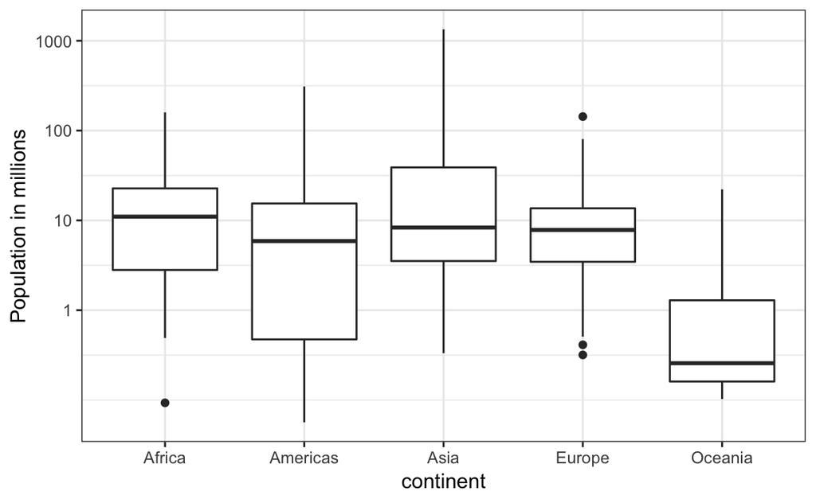

image

Which continent has the country with the biggest population size?

###### Asia

4. What continent has the largest median population size?

###### Africa

5. What is median population size for Africa to the nearest million?

###### ~10

6. What proportion of countries in Europe have populations below 14 million?

A. 0.99

**B. 0.75**

C. 0.50

D. 0.25

7. If we use a log transformation, which continent shown above has the largest interquartile range?

> America
8. Load the height data set and create a vector `x` with just the male heights:

```r
x <- heights %>% height[sex=="Male"]
```

```
Error in `[.data.frame`(., height, sex == "Male") :
  object 'sex' not found
```

What proportion of the data is between 69 and 72 inches (taller than 69, but shorter or equal to 72)? Hint: use a logical operator and `mean`.

```r
mean(q)
```

```
[1] 0.3337438
```

9. Suppose all you know about the data is the average and the standard deviation. Use the normal approximation to estimate the proportion you just calculated. Hint: start by computing the average and standard deviation. Then use the `pnorm` function to predict the proportions.

```r
p[1] - p[2]
```

```
[1] 0.3061779
```

10. Notice that the approximation calculated in question two is very close to the exact calculation in the first question. Now perform the same task for more extreme values. Compare the exact calculation and the normal approximation for the interval (79,81]. How many times bigger is the actual proportion than the approximation?

```r
p_ob / p_ex
```

```
[1] 1.614261
```

11. Approximate the distribution of adult men in the world as normally distributed with an average of 69 inches and a standard deviation of 3 inches. Using this approximation, estimate the proportion of adult men that are 7 feet tall or taller, referred to as seven footers. Hint: use the `pnorm` function.

```r
p_7feet
```

```
[1] 2.866516e-07
```

12. There are about 1 billion men between the ages of 18 and 40 in the world. Use your answer to the previous question to estimate how many of these men (18-40 year olds) are seven feet tall or taller in the world?

```r
as.integer(1 * 10^9 * p_7feet)
```

```
[1] 286
```

13. There are about 10 National Basketball Association (NBA) players that are 7 feet tall or higher. Using the answer to the previous two questions, what proportion of the world’s 18 to 40 year old seven footers are in the NBA?

```r
10 / (1*10^9*p_7feet)
```

```
[1] 0.03488556
```

14. Repeat the calculations performed in the previous question for Lebron James’ height: 6 feet 8 inches. There are about 150 players that are at least that tall.

```r
150 /(10^9*(1 - p_J))
```

```
[1] 0.001220838
```

15. In answering the previous questions, we found that it is not at all rare for a seven footer to become an NBA player. What would be a fair critique of our calculations:

A. Practice and talent are what make a great basketball player, not height.

B. The normal approximation is not appropriate for heights.

**C. As seen in question 3, the normal approximation tends to underestimate the extreme values. It’s possible that there are more seven footers than we predicted.**

D. As seen in question 3, the normal approximation tends to overestimate the extreme values. It’s possible that there are less seven footers than we predicted.

# **9.16 ggplot2 geometries**

## 9.16.1 Barplots

```r
murders %>% ggplot(aes(region)) + geom_bar()
```

```r
murders %>% count(region) %>%
    mutate(proportion = n/sum(n)) %>%
    ggplot(aes(region, proportion)) +
    geom_bar(stat = "identity")
# stat = "identity" : provide x and y to geom_bar
```

## 9.16.2 Histograms

```r
heights %>%
    filter(sex == "Female") %>%
    ggplot(aes(height)) +
    geom_histogram()
```

- adjust binwidth with `binwidth`

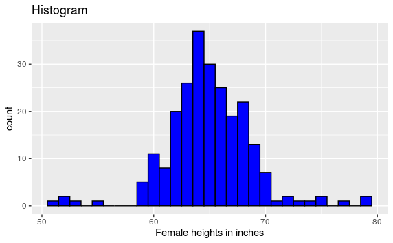

[figure not shown]

## 9.16.3 Density plots

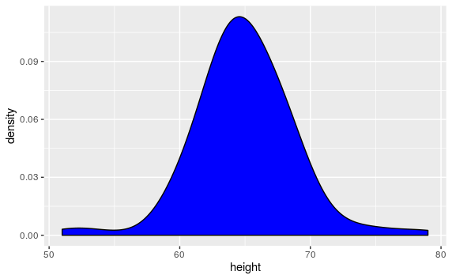

- adjust smoothness by `adjust =` argument.

## 9.16.4 Boxplots

[figure not shown]

## 9.16.5 QQ-plots

- `geom_qq()`
  - By default, the sample variable is compared to a normal distribution with average 0 and standard deviation 1.
  - `dparams` : adjust the type of normal distribution
  - `geom_abline` : trend lin (default : slope=1, intercept=0)
  - `scale()` method of `aes` : scale the data first and then make a qqplot against the standard normal.

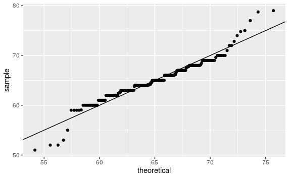

[output not shown]

[output cut: 110 more lines]

## 9.16.6 Images

> **geom_tile** **geom_raster**

```r
matrix(1:120, 12, 10)
```

```
      [,1] [,2] [,3] [,4] [,5] [,6] [,7] [,8] [,9] [,10]
 [1,]    1   13   25   37   49   61   73   85   97   109
 [2,]    2   14   26   38   50   62   74   86   98   110
 [3,]    3   15   27   39   51   63   75   87   99   111
 [4,]    4   16   28   40   52   64   76   88  100   112
 [5,]    5   17   29   41   53   65   77   89  101   113
 [6,]    6   18   30   42   54   66   78   90  102   114
 [7,]    7   19   31   43   55   67   79   91  103   115
 [8,]    8   20   32   44   56   68   80   92  104   116
 [9,]    9   21   33   45   57   69   81   93  105   117
[10,]   10   22   34   46   58   70   82   94  106   118
[11,]   11   23   35   47   59   71   83   95  107   119
[12,]   12   24   36   48   60   72   84   96  108   120
```

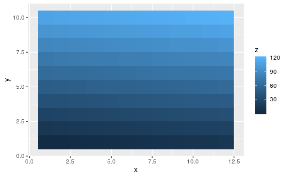

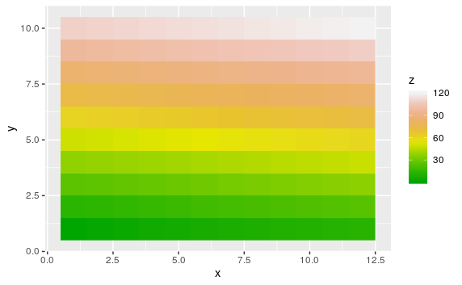

[figure not shown]

## 9.16.7 Quick plots

> Quick plots은 적폐입니다.

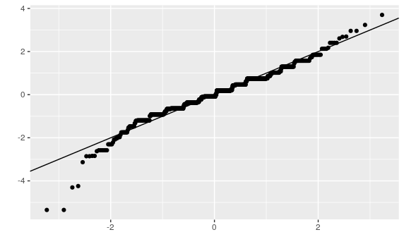

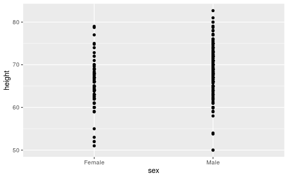

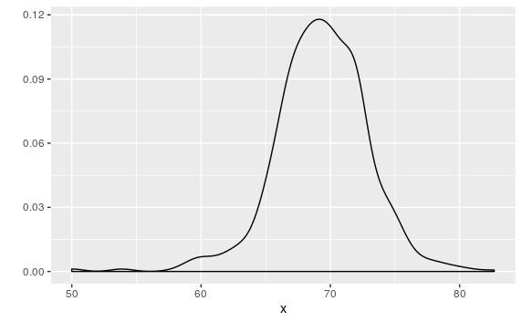

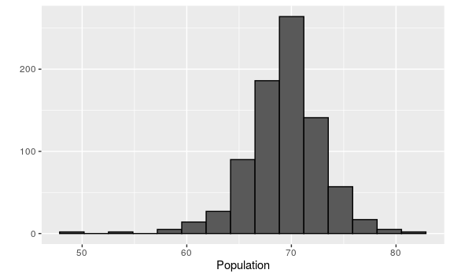

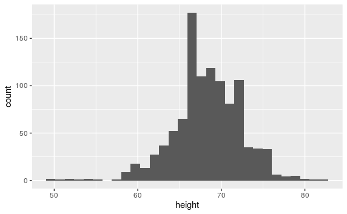

- Technical note : `I("black")`, `aes`에 의하여 factor로 자동변환되는 것을 방지

> function `I` in R : “keep it as it is”

# 9.17 Exercises

1. Now we are going to use the `geom_histogram` function to make a histogram of the `heights` in the height data frame. When reading the documentation for this function we see that it requires just one mapping, the values to be used for the histogram. Make a histogram of all the plots. What is the variable containing the heights?

A. sex

B. heights

**C. height**

D. heights$height

2. Now create a ggplot object using the pipe to assign the heights data to a ggplot object. Assign `height` to the x values through the `aes` function.

```
heights %>% ggplot(aes(height))
```

3. Now we are ready to add a layer to actually make the histogram. Use the object created in the previous exercise and the `geom_histogram` function to make the histogram.

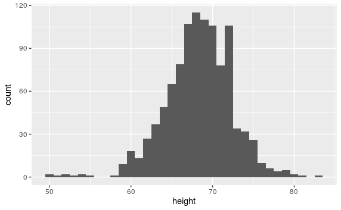

4. Note that when we run the code in the previous exercise we get the warning: `stat_bin()` using `bins = 30`. Pick better value with `binwidth`.

Use the `binwidth` argument to change the histogram made in the previous exercise to use bins of size 1 inch.

[figure not shown]

5. Instead of a histogram, we are going to make a smooth density plot. In this case we will not make an object, but instead render the plot with one line of code. Change the geometry in the code previously used to make a smooth density instead of a histogram.

[figure not shown]

6. Now we are going to make a density plot for males and females separately. We can do this using the `group` argument. We assign groups via the aesthetic mapping as each point needs to a group before making the calculations needed to estimate a density.

[figure not shown]

7. We can also assign groups through the `color` argument. This has the added benefit that it uses color to distinguish the groups. Change the code above to use color.

[figure not shown]

8. We can also assign groups through the fill argument. This has the added benefit that it uses colors to distinguish the groups, like this:

[figure not shown]

However, here the second density is drawn over the other. We can make the curves more visible by using alpha blending to add transparency. Set the alpha parameter to 0.2 in the geom_density function to make this change.

```r
heights %>%
    ggplot(aes(height, color=sex, fill=sex)) +
    geom_density(alpha = 0.2)
```